# Survey data summary

data: simulationOutput dispersion = 0.69801, p-value = 0.864 alternative hypothesis: two.sided

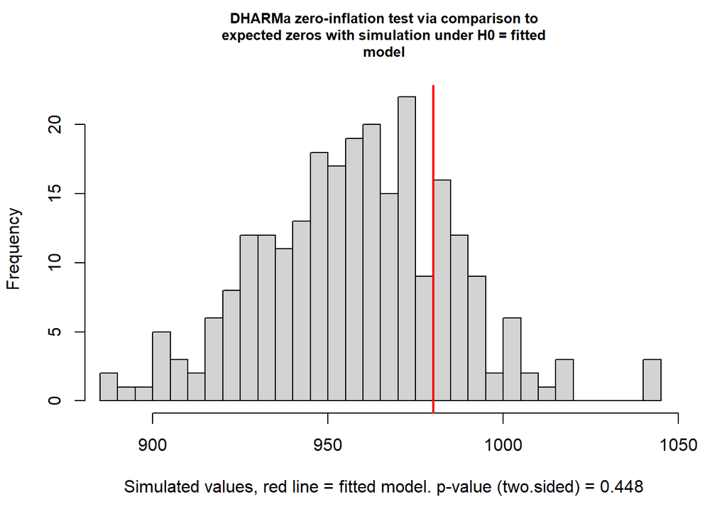

DHARMa zero-inflation test via comparison to expected zeros with simulation under H0 = fitted model

data: simulationOutput ratioObsSim = 1.0225, p-value = 0.448 alternative hypothesis: two.sided

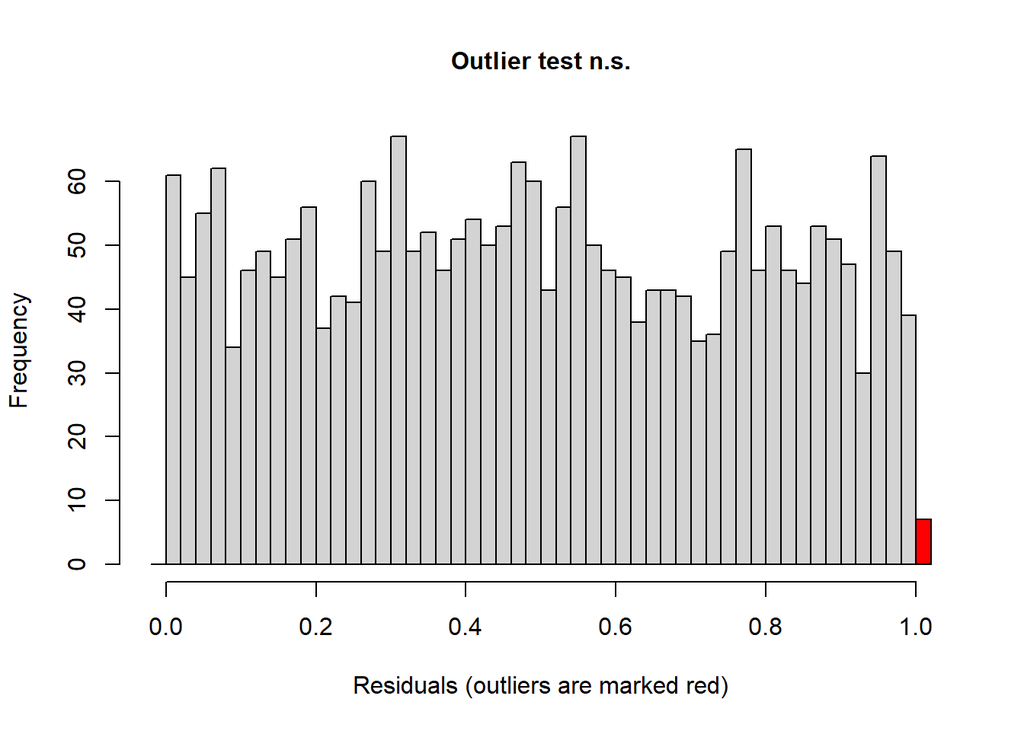

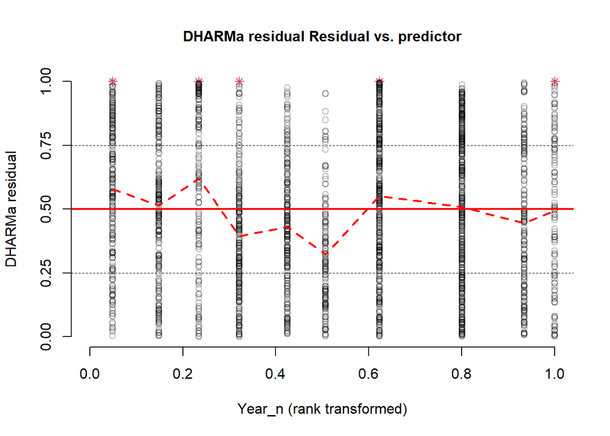

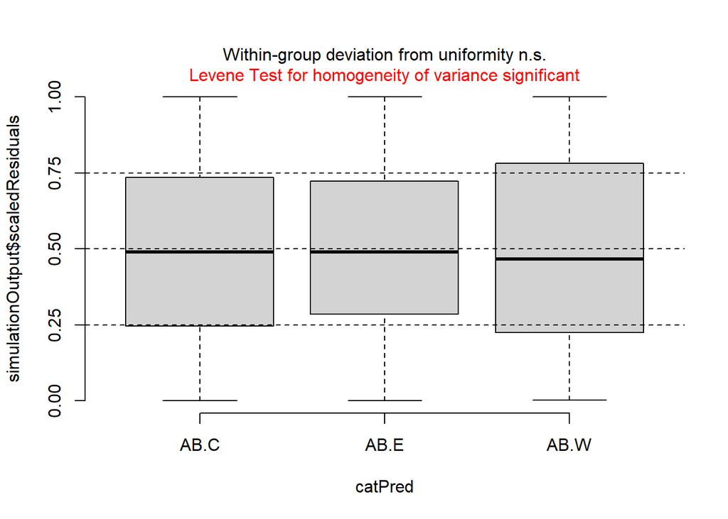

outliers at both margin(s) 18  
Parameter: observations 2465  
p_value: [1] 0.820589  
Conf int: [1] 0.004333339 0.011516209 attr(,“conf.level”) [1] 0.95

Apalachicola model results

| term | statistic | df | p.value |
| --- | --- | --- | --- |
| SectionID | 12.530 | 2.000 | 0.002 |
| Year_c | 2.475 | 1.000 | 0.116 |
| Quarter | 3.975 | 1.000 | 0.046 |
| SectionID:Year_c | 15.180 | 2.000 | 0.001 |

**Linear Model post-hoc:**  
Q: Does oyster abundance differ among Sections after accounting for Year and Quarter?  
*Estimated marginal means*: Adjusted means accounting for year, quarter, random effects, and zero-inflation.

Emmeans on response scale:

| SectionID | Year_c.trend | SE | df | asymp.LCL | asymp.UCL | annual_pct_change |
| --- | --- | --- | --- | --- | --- | --- |
| AB.C | −0.041 | 0.021 | Inf | −0.082 | 0.000 | −4.020 |
| AB.E | 0.066 | 0.020 | Inf | 0.027 | 0.105 | 6.825 |
| AB.W | 0.044 | 0.028 | Inf | −0.011 | 0.100 | 4.520 |

Which sections have different trends?

| contrast | estimate | SE | df | z.ratio | p.value | Significance |
| --- | --- | --- | --- | --- | --- | --- |
| AB.C - AB.E | −0.107 | 0.028 | Inf | −3.784 | 0.000 | *** |
| AB.C - AB.W | −0.085 | 0.035 | Inf | −2.443 | 0.039 | * |
| AB.E - AB.W | 0.022 | 0.034 | Inf | 0.634 | 0.801 |  |

Q: Is oyster density increasing or decreasing over time within Sections?:

| SectionID | annual_percent_change | p.value |
| --- | --- | --- |
| AB.C | −4.020 | 0.048 |
| AB.E | 6.825 | 0.001 |
| AB.W | 4.520 | 0.118 |

Years surveyed per Section

| SectionID | min_year | max_year | n_years |
| --- | --- | --- | --- |
| AB.C | 10.000 | 19.000 | 9.000 |
| AB.E | 10.000 | 19.000 | 9.000 |
| AB.W | 10.000 | 19.000 | 10.000 |

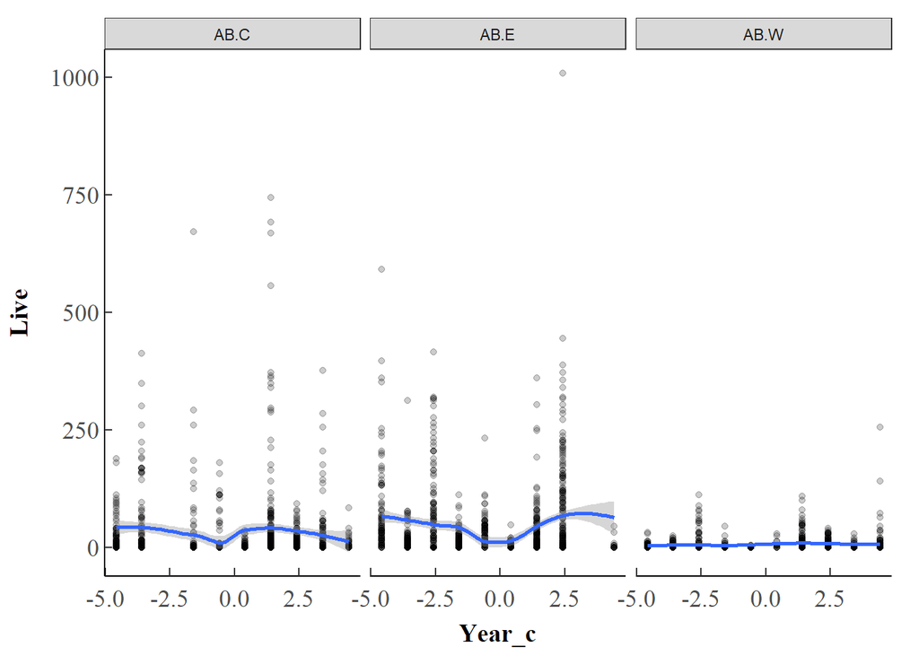

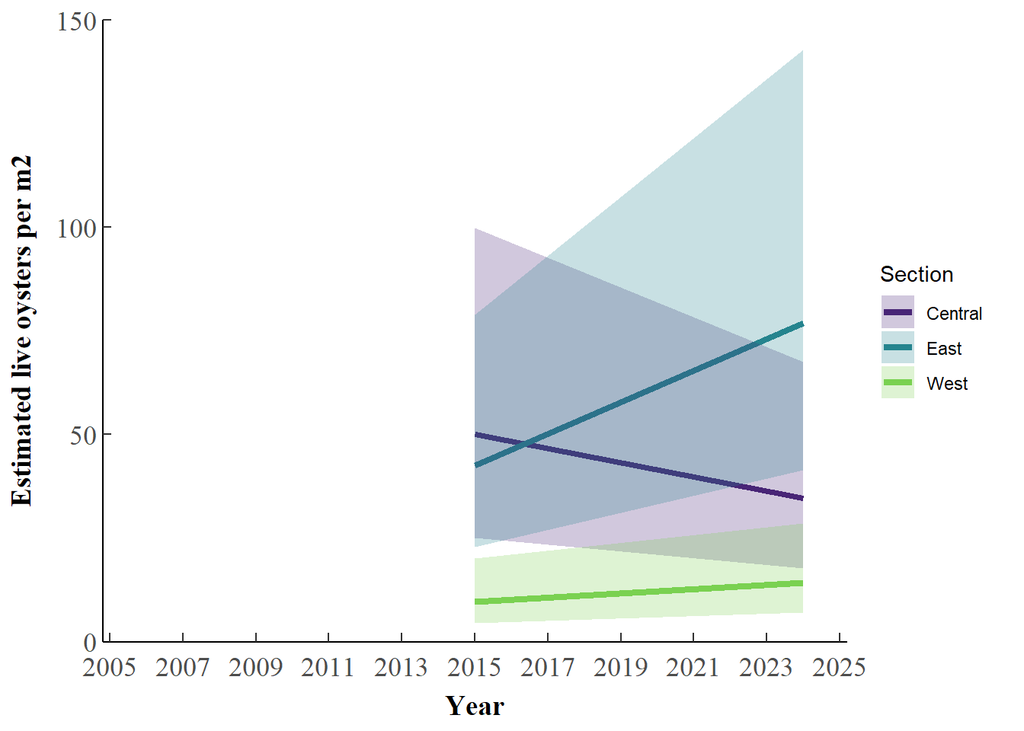

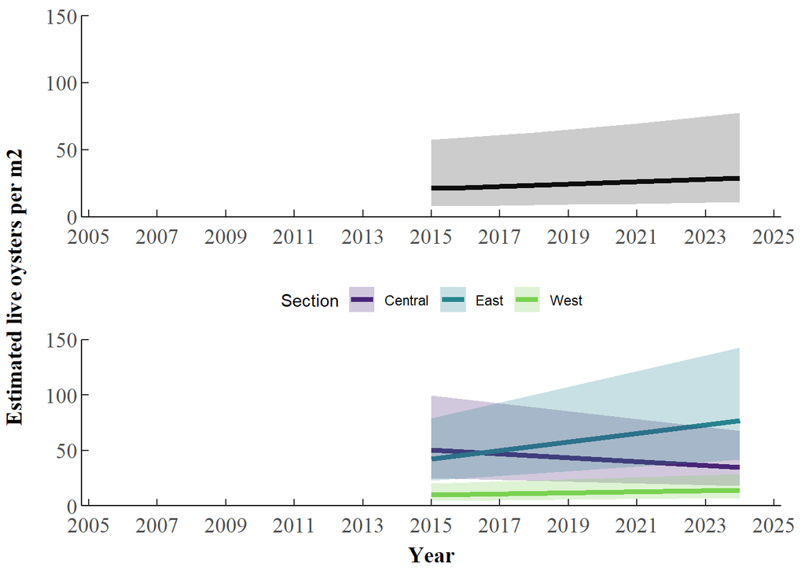

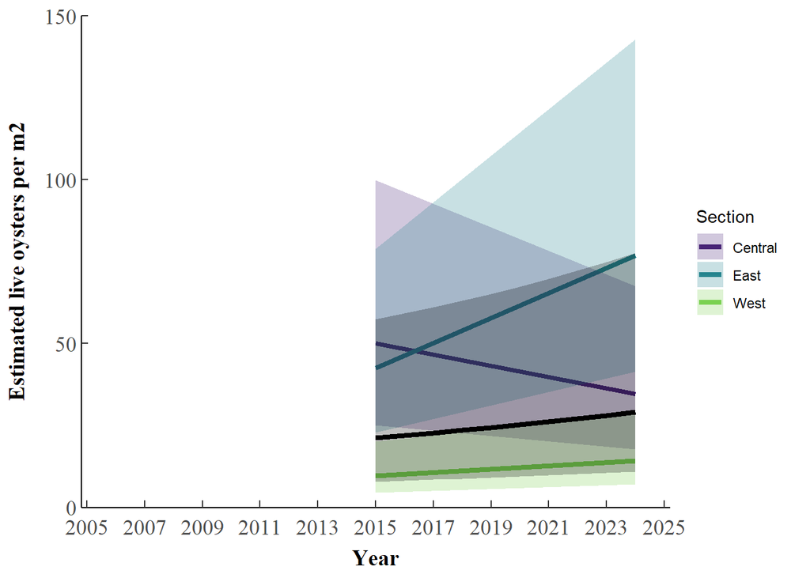

### Sections (spline)

**Spline model assessment:**  
Residuals:

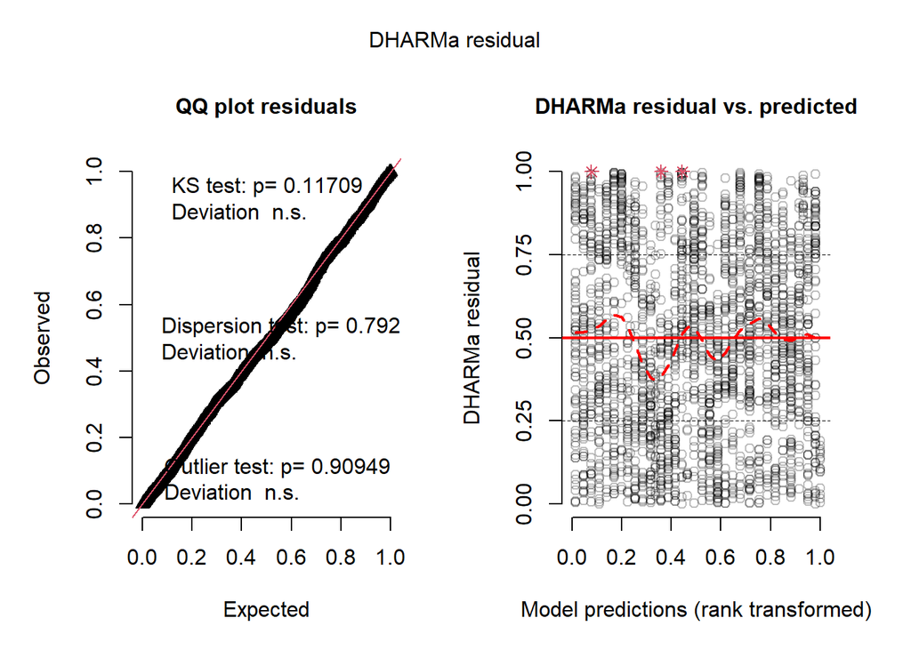

Overdispersion:  
Dispersion ratio > 1 → overdispersion  
Dispersion ratio < 1 → underdispersion

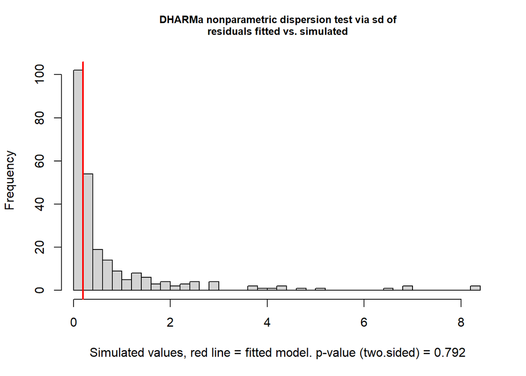

DHARMa nonparametric dispersion test via sd of residuals fitted vs. simulated

data: simulationOutput dispersion = 0.24692, p-value = 0.792 alternative hypothesis: two.sided

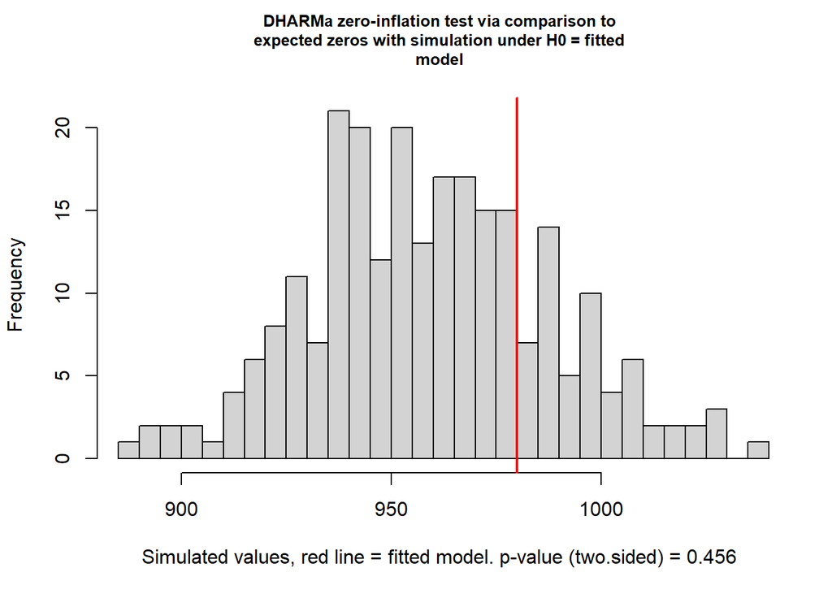

DHARMa zero-inflation test via comparison to expected zeros with simulation under H0 = fitted model

data: simulationOutput ratioObsSim = 1.0213, p-value = 0.456 alternative hypothesis: two.sided

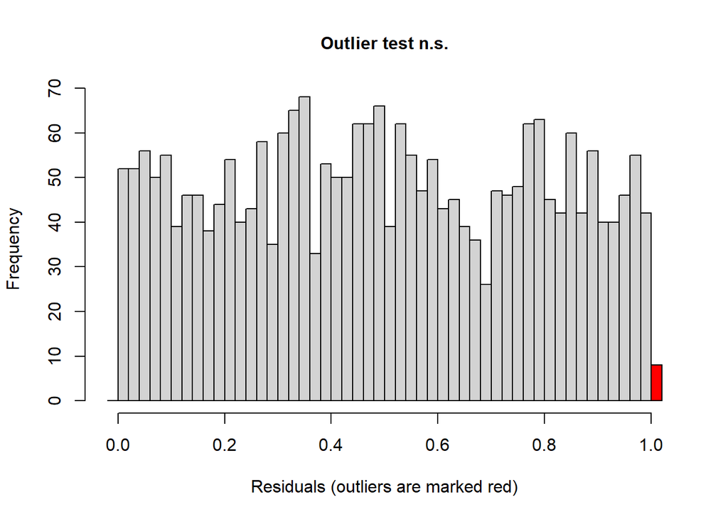

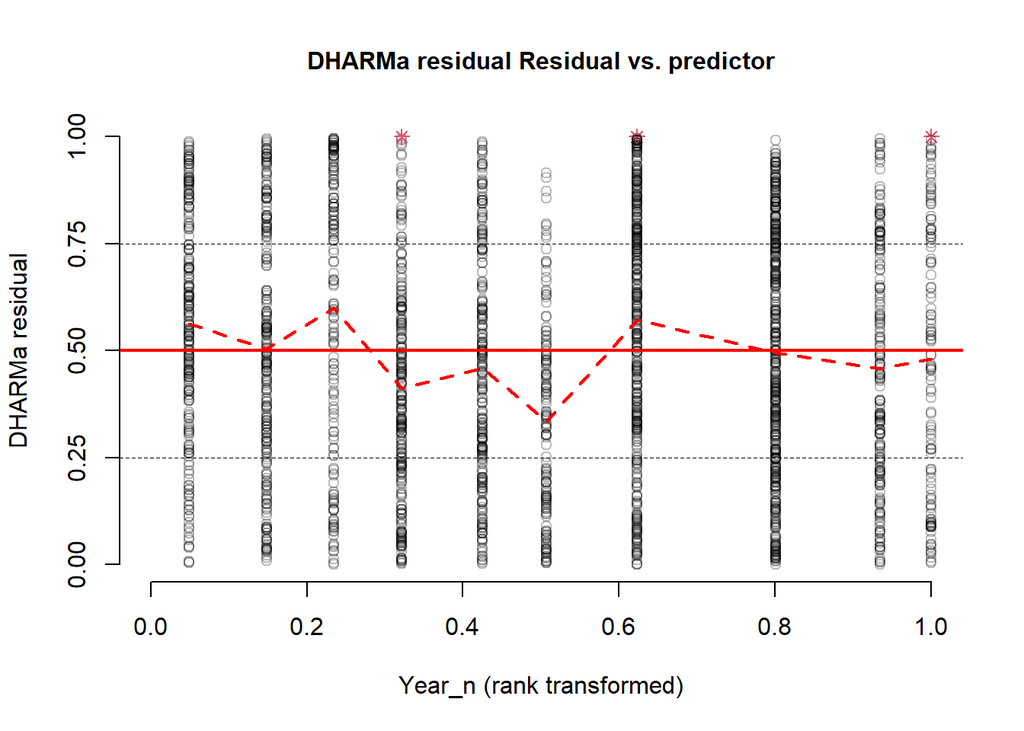

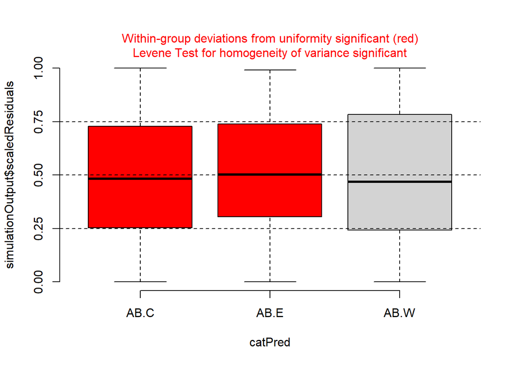

outliers at both margin(s) 20  
Parameter: observations 2465  
p_value: [1] 0.9094949  
Conf int: [1] 0.004962832 0.012503095 attr(,“conf.level”) [1] 0.95

Apalachicola model results

| term | statistic | df | p.value |
| --- | --- | --- | --- |
| SectionID | 14.224 | 2.000 | 0.001 |
| splines::ns(Year_c, df = 3) | 18.222 | 3.000 | 0.000 |
| Quarter | 0.534 | 1.000 | 0.465 |
| SectionID:splines::ns(Year_c, df = 3) | 64.769 | 6.000 | 0.000 |

**Spline Model post-hoc:**  
Q: Does oyster abundance differ among Sections after accounting for Year and Quarter?  
*Estimated marginal means*: Adjusted means accounting for year, quarter, random effects, and zero-inflation. At each year, which Sections differed in estimated live oyster density?

Emmeans on response scale:

[output not shown]

| contrast | Year_c | ratio | SE | df | null | z.ratio | p.value | Significance |
| --- | --- | --- | --- | --- | --- | --- | --- | --- |
| AB.C / AB.E | -4.58012170385395 | 0.934 | 0.444 | Inf | 1.000 | −0.143 | 0.989 |  |
| AB.C / AB.W | -4.58012170385395 | 11.669 | 6.158 | Inf | 1.000 | 4.656 | 0.000 | *** |
| AB.E / AB.W | -4.58012170385395 | 12.490 | 6.262 | Inf | 1.000 | 5.036 | 0.000 | *** |
| AB.C / AB.E | 0.419878296146045 | 1.066 | 0.478 | Inf | 1.000 | 0.143 | 0.989 |  |
| AB.C / AB.W | 0.419878296146045 | 2.189 | 1.035 | Inf | 1.000 | 1.658 | 0.222 |  |
| AB.E / AB.W | 0.419878296146045 | 2.053 | 0.930 | Inf | 1.000 | 1.588 | 0.251 |  |
| AB.C / AB.E | 4.41987829614605 | 0.027 | 0.019 | Inf | 1.000 | −4.985 | 0.000 | *** |
| AB.C / AB.W | 4.41987829614605 | 3.373 | 1.786 | Inf | 1.000 | 2.296 | 0.056 |  |
| AB.E / AB.W | 4.41987829614605 | 125.679 | 90.336 | Inf | 1.000 | 6.725 | 0.000 | *** |

Start vs End estimated means comps:

| contrast | SectionID | ratio | SE | df | null | z.ratio | p.value | Significance |
| --- | --- | --- | --- | --- | --- | --- | --- | --- |
| (Year_c-4.58012170385395) / Year_c4.41987829614605 | AB.C | 1.580 | 0.443 | Inf | 1.000 | 1.631 | 0.103 |  |
| (Year_c-4.58012170385395) / Year_c4.41987829614605 | AB.E | 0.045 | 0.026 | Inf | 1.000 | −5.489 | 0.000 | *** |
| (Year_c-4.58012170385395) / Year_c4.41987829614605 | AB.W | 0.457 | 0.142 | Inf | 1.000 | −2.526 | 0.012 | * |

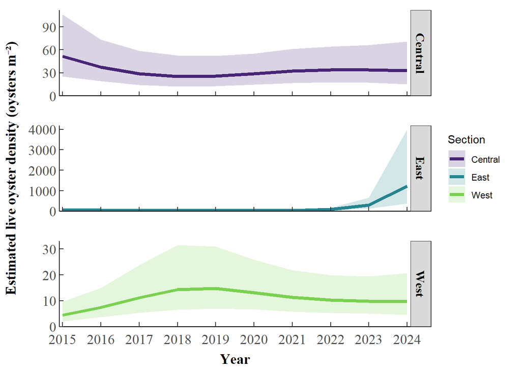

# Gulf Coast estuaries

## Tampa Bay

### Estuary-wide

**Background information:**

Average live oyster density

| Year | Mean | SE |
| --- | --- | --- |
| 2005 | 145.67 | 18.59 |
| 2006 | 305.04 | 35.50 |
| 2007 | 282.78 | 24.51 |
| 2016 | 1,058.88 | 47.24 |
| 2017 | 927.49 | 58.94 |
| 2018 | 1,027.65 | 45.63 |
| 2019 | 811.79 | 48.08 |
| 2020 | 815.76 | 53.04 |
| 2021 | 538.43 | 47.62 |
| 2022 | 382.72 | 37.85 |
| 2023 | 1,247.20 | 148.87 |
| 2024 | 809.27 | 104.16 |
| 2025 | 932.05 | 93.51 |

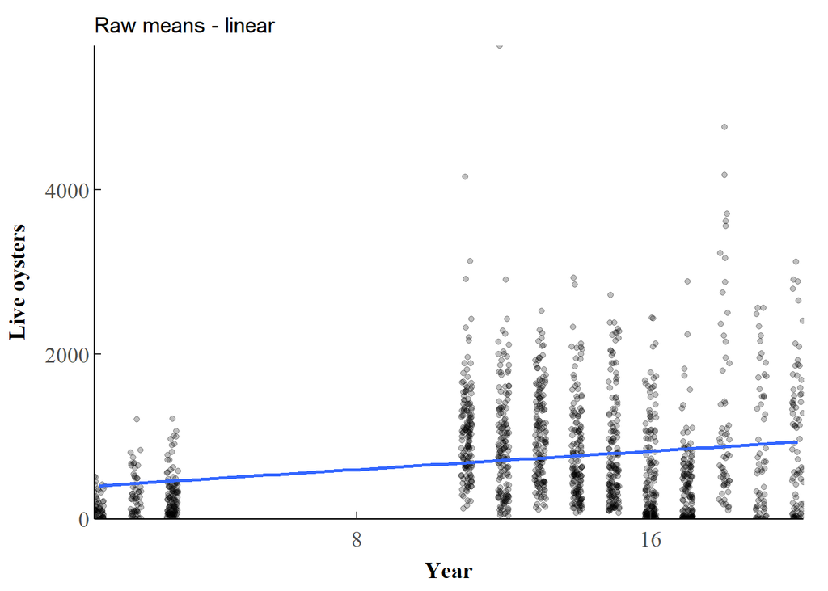

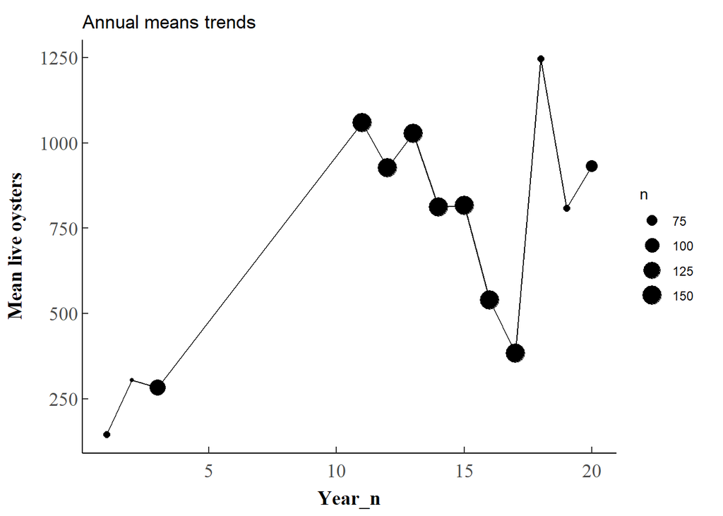

Amount of 0s

| Year | n | zeros | zero_pct | mean |
| --- | --- | --- | --- | --- |
| 2005 | 60.00 | 6.00 | 10.00 | 145.67 |
| 2006 | 56.00 | 2.00 | 3.57 | 305.04 |
| 2007 | 115.00 | 1.00 | 0.87 | 282.78 |
| 2016 | 150.00 | 0.00 | 0.00 | 1,058.88 |
| 2017 | 150.00 | 0.00 | 0.00 | 927.49 |
| 2018 | 150.00 | 0.00 | 0.00 | 1,027.65 |
| 2019 | 150.00 | 0.00 | 0.00 | 811.79 |
| 2020 | 150.00 | 0.00 | 0.00 | 815.76 |
| 2021 | 150.00 | 1.00 | 0.67 | 538.43 |
| 2022 | 150.00 | 14.00 | 9.33 | 382.72 |
| 2023 | 60.00 | 0.00 | 0.00 | 1,247.20 |
| 2024 | 60.00 | 4.00 | 6.67 | 809.27 |
| 2025 | 80.00 | 0.00 | 0.00 | 932.05 |

**Analyses:**  
GLMM model with negative binomial distribution, log link Fixed effects - Year, Quarter  
Random effects - Station (sampling unit)  
Year = continuous to identify trend. Centered to interpret trend at middle timepoint of surveys.  
*Has density changed over time?*

Standard vs 0-inflated

|  | df | AIC |
| --- | --- | --- |
| TBm0 | 6 | 22138.24 |
| TBm01 | 8 | 22046.14 |

**Estuary model assessment:** TBm0  
Residuals:

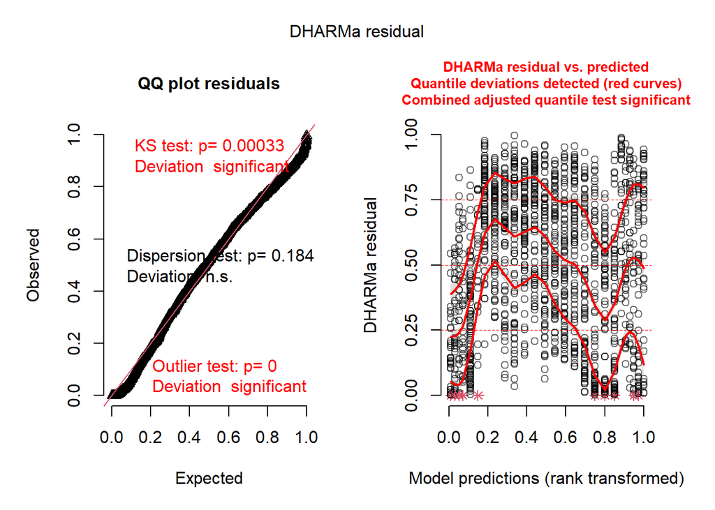

Overdispersion:  
Dispersion ratio > 1 → overdispersion  
Dispersion ratio < 1 → underdispersion

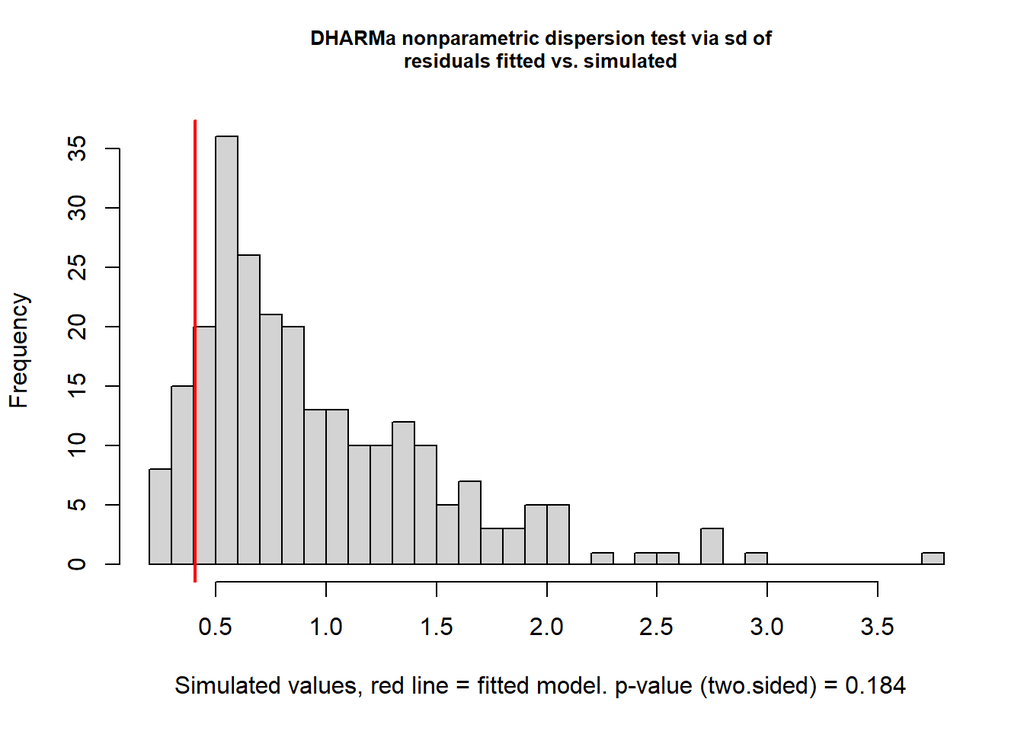

DHARMa nonparametric dispersion test via sd of residuals fitted vs. simulated

data: simulationOutput dispersion = 0.42621, p-value = 0.184 alternative hypothesis: two.sided

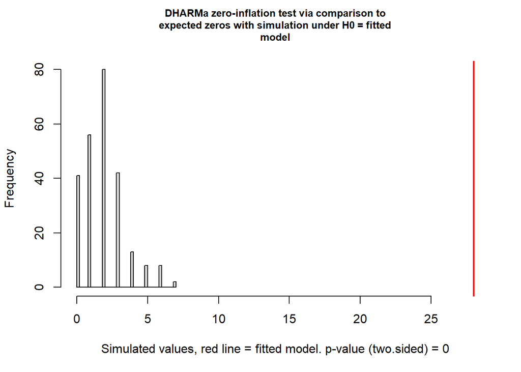

DHARMa zero-inflation test via comparison to expected zeros with simulation under H0 = fitted model

data: simulationOutput ratioObsSim = 14.113, p-value < 2.2e-16 alternative hypothesis: two.sided

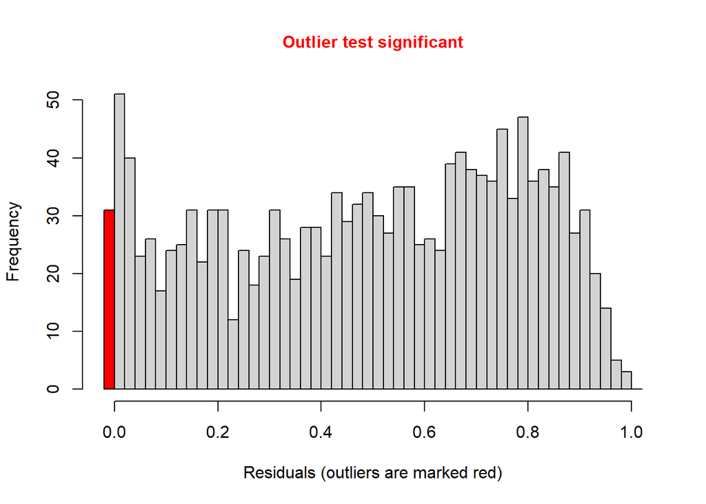

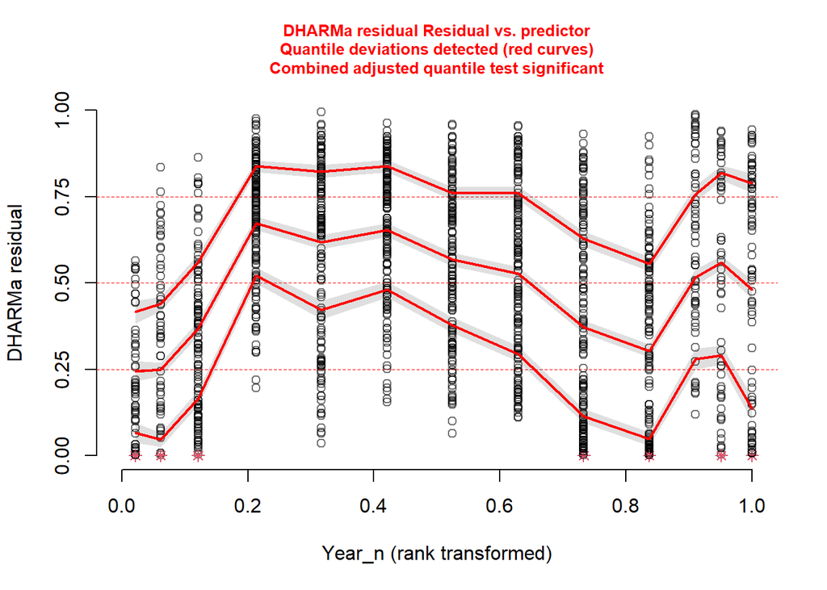

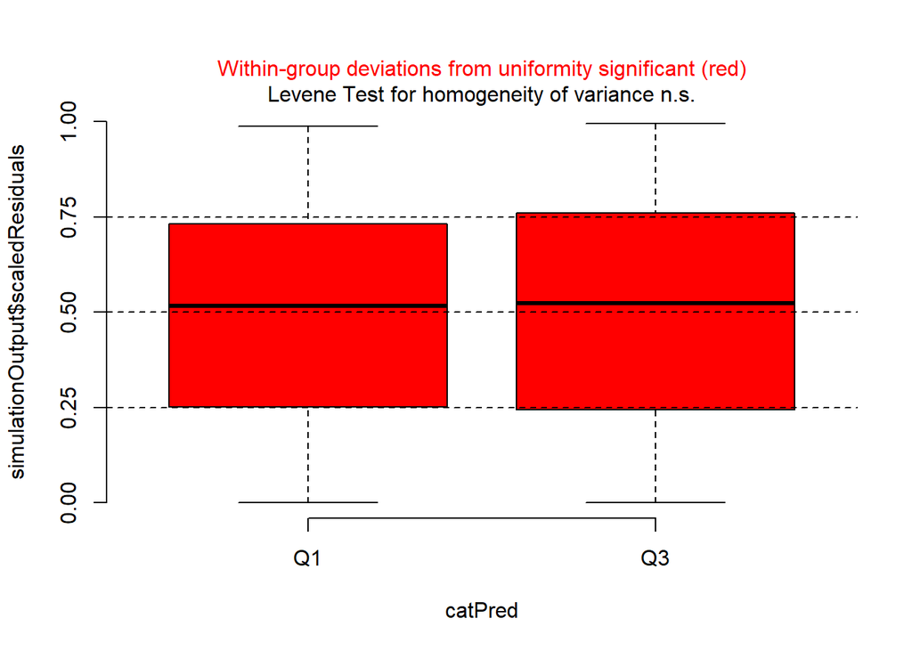

outliers at both margin(s) 39  
Parameter: observations 1481  
p_value: [1] 2.584956e-10  
Conf int: [1] 0.01879124 0.03582433 attr(,“conf.level”) [1] 0.95

Tampa Bay estuary-wide model results

| term | statistic | df | p.value |
| --- | --- | --- | --- |
| Year_c | 9.856 | 1.000 | 0.002 |
| Quarter | 0.098 | 1.000 | 0.754 |

**Model post-hoc:**  
Q: Has oyster abundance changed over time after accounting for Quarter?  
*Estimated marginal means*: Adjusted means accounting for quarter, random effects, and zero-inflation.

Emmeans on response scale:

| 1 | Year_c.trend | SE | df | asymp.LCL | asymp.UCL | annual_pct_change |
| --- | --- | --- | --- | --- | --- | --- |
| overall | 0.021 | 0.007 | Inf | 0.008 | 0.035 | 2.147 |

1 Year_c.trend SE df z.ratio p.value overall 0.0212 0.00677 Inf 3.139 0.0017

Results are averaged over the levels of: Quarter  
There is evidence of an overall increasing temporal trend.

Trend significance

| contrast | ratio | SE | df | null | z.ratio | p.value | Significance |
| --- | --- | --- | --- | --- | --- | --- | --- |
| (Year_c-11.8541525995949) / Year_c7.14584740040513 | 0.668 | 0.086 | Inf | 1.000 | −3.139 | 0.002 | ** |

| Year | Year_n | Year_c |
| --- | --- | --- |
| 2005 | 1 | -11.8541526 |
| 2006 | 2 | -10.8541526 |
| 2007 | 3 | -9.8541526 |
| 2016 | 11 | -1.8541526 |
| 2017 | 12 | -0.8541526 |
| 2018 | 13 | 0.1458474 |
| 2019 | 14 | 1.1458474 |
| 2020 | 15 | 2.1458474 |
| 2021 | 16 | 3.1458474 |
| 2022 | 17 | 4.1458474 |
| 2023 | 18 | 5.1458474 |
| 2024 | 19 | 6.1458474 |
| 2025 | 20 | 7.1458474 |

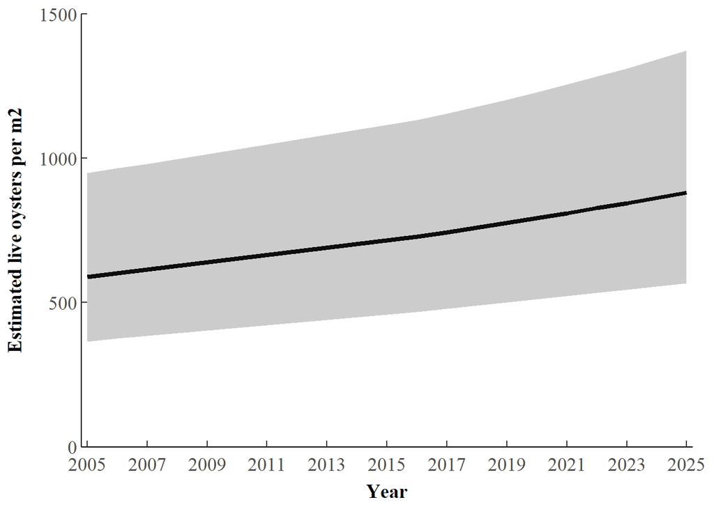

### Sections (linear)

**Background information:**

Average live oyster density

| Year | Mean | SE |
| --- | --- | --- |
| 2005 | 145.67 | 18.59 |
| 2006 | 305.04 | 35.50 |
| 2007 | 282.78 | 24.51 |
| 2016 | 1,058.88 | 47.24 |
| 2017 | 927.49 | 58.94 |
| 2018 | 1,027.65 | 45.63 |
| 2019 | 811.79 | 48.08 |
| 2020 | 815.76 | 53.04 |
| 2021 | 538.43 | 47.62 |
| 2022 | 382.72 | 37.85 |
| 2023 | 1,247.20 | 148.87 |
| 2024 | 809.27 | 104.16 |
| 2025 | 932.05 | 93.51 |

Annual observations per Section

| SectionID | 2016 | 2017 | 2018 | 2019 | 2020 | 2021 | 2022 | 2023 | 2024 | 2025 | 2005 | 2006 | 2007 |
| --- | --- | --- | --- | --- | --- | --- | --- | --- | --- | --- | --- | --- | --- |
| TB.B | 30 | 30 | 30 | 30 | 30 | 30 | 30 | 10 | 10 | 10 | 0 | 0 | 0 |
| TB.L | 90 | 90 | 90 | 90 | 90 | 90 | 90 | 20 | 20 | 40 | 60 | 56 | 115 |
| TB.M | 30 | 30 | 30 | 30 | 30 | 30 | 30 | 10 | 10 | 10 | 0 | 0 | 0 |
| TB.R | 0 | 0 | 0 | 0 | 0 | 0 | 0 | 20 | 20 | 20 | 0 | 0 | 0 |

Stations per Section

| SectionID | Stations |
| --- | --- |
| TB.B | 1 |
| TB.L | 4 |
| TB.M | 1 |
| TB.R | 2 |

Observations per Section

| SectionID | Observations |
| --- | --- |
| TB.B | 240 |
| TB.L | 941 |
| TB.M | 240 |
| TB.R | 60 |

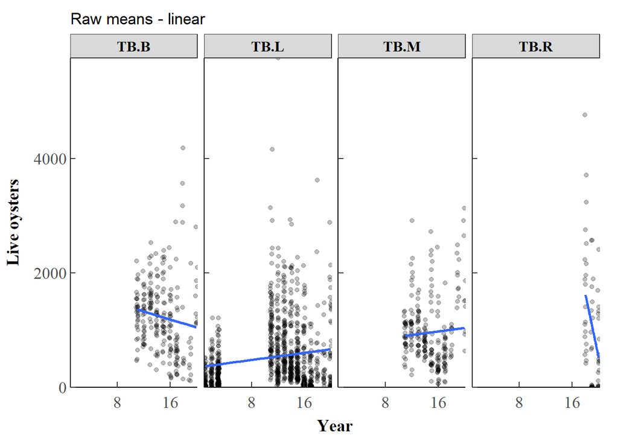

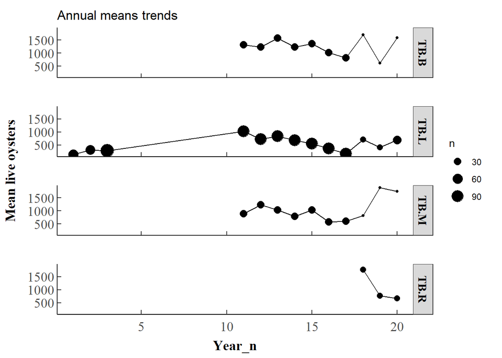

Amount of 0s

| SectionID | n | zeros | zero_pct | mean |
| --- | --- | --- | --- | --- |
| TB.B | 240.00 | 0.00 | 0.00 | 1,233.67 |
| TB.L | 941.00 | 24.00 | 2.55 | 533.01 |
| TB.M | 240.00 | 0.00 | 0.00 | 955.20 |
| TB.R | 60.00 | 4.00 | 6.67 | 1,063.60 |

**Analyses:**  
Fixed effects - Section  
Random effects - Station (sampling unit)  
Year = continuous to identify trend. Centered to interpret trend at middle timepoint of surveys.  
*Do estuary Sections differ?*

Standard vs 0-inflated

|  | df | AIC |
| --- | --- | --- |
| TBm1 | 8 | 22135.55 |
| TBm2 | 13 | 22025.27 |

Few zeros so not using zero-inlfated model.

Do Sections have different trends?

|  | Df | AIC | BIC | logLik | deviance | Chisq | Chi Df | Pr(>Chisq) |
| --- | --- | --- | --- | --- | --- | --- | --- | --- |
| TBm1 | 8 | 22135.55 | 22177.96 | -11059.78 | 22119.55 | NA | NA | NA |
| TBm3 | 11 | 22125.23 | 22183.54 | -11051.62 | 22103.23 | 16.32343 | 3 | 0.0009733346 |

Linear vs Spline (df=3) trend?

|  | df | AIC |
| --- | --- | --- |
| TBm3 | 11 | 22125.23 |
| TBm4 | 18 | 21795.94 |

Are splines better?

|  | Df | AIC | BIC | logLik | deviance | Chisq | Chi Df | Pr(>Chisq) |
| --- | --- | --- | --- | --- | --- | --- | --- | --- |
| TBm3 | 11 | 22125.23 | 22183.54 | -11051.62 | 22103.23 | NA | NA | NA |
| TBm4 | 18 | 21795.94 | 21891.34 | -10879.97 | 21759.94 | 343.2949 | 7 | 3.355844e-70 |

**Linear model assessment:**  
Residuals:

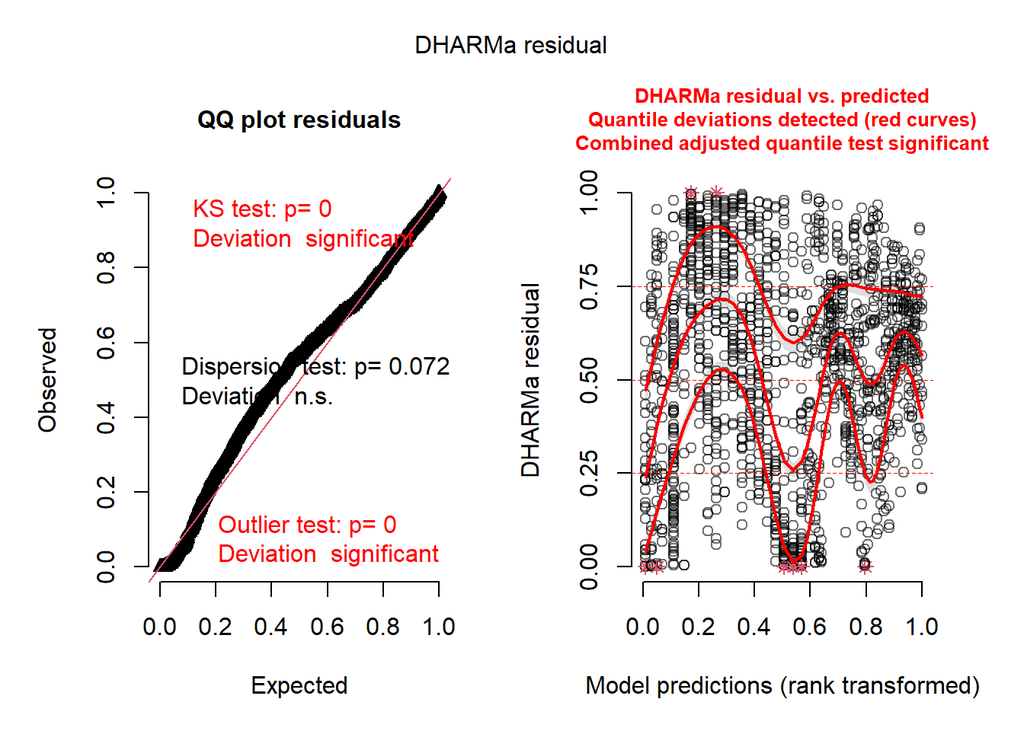

Overdispersion:  
Dispersion ratio > 1 → overdispersion  
Dispersion ratio < 1 → underdispersion

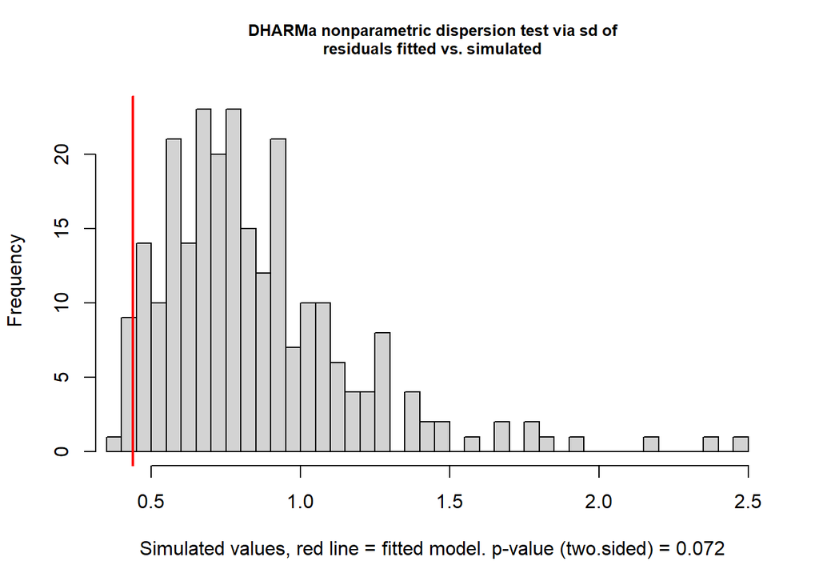

DHARMa nonparametric dispersion test via sd of residuals fitted vs. simulated

data: simulationOutput dispersion = 0.51726, p-value = 0.072 alternative hypothesis: two.sided

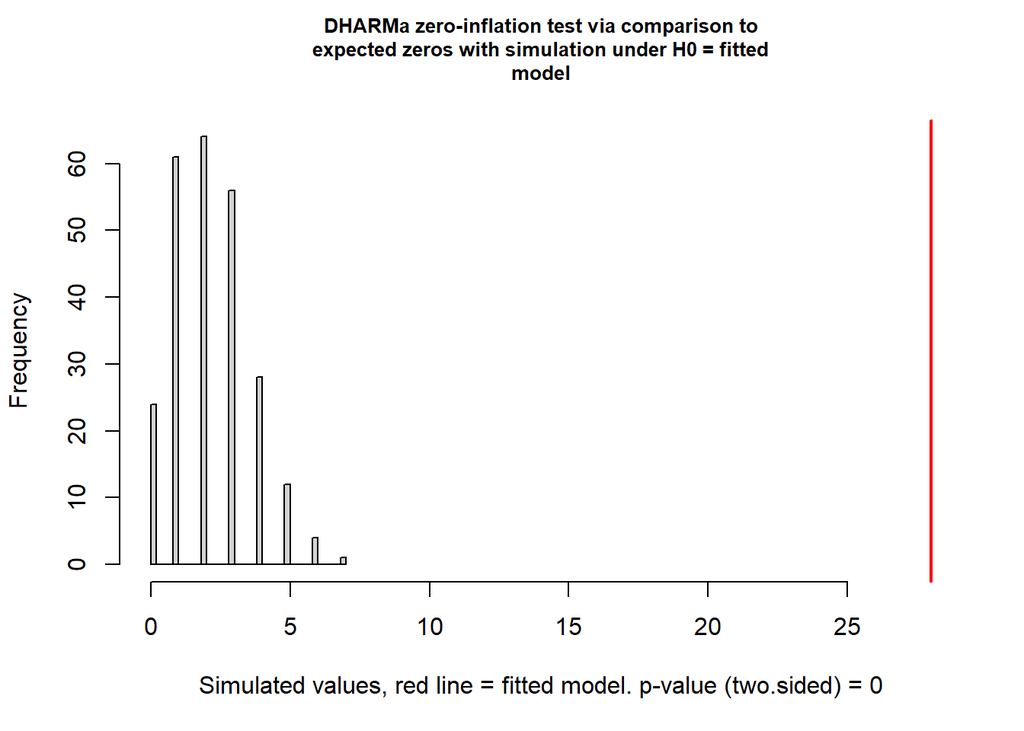

DHARMa zero-inflation test via comparison to expected zeros with simulation under H0 = fitted model

data: simulationOutput ratioObsSim = 12.5, p-value < 2.2e-16 alternative hypothesis: two.sided

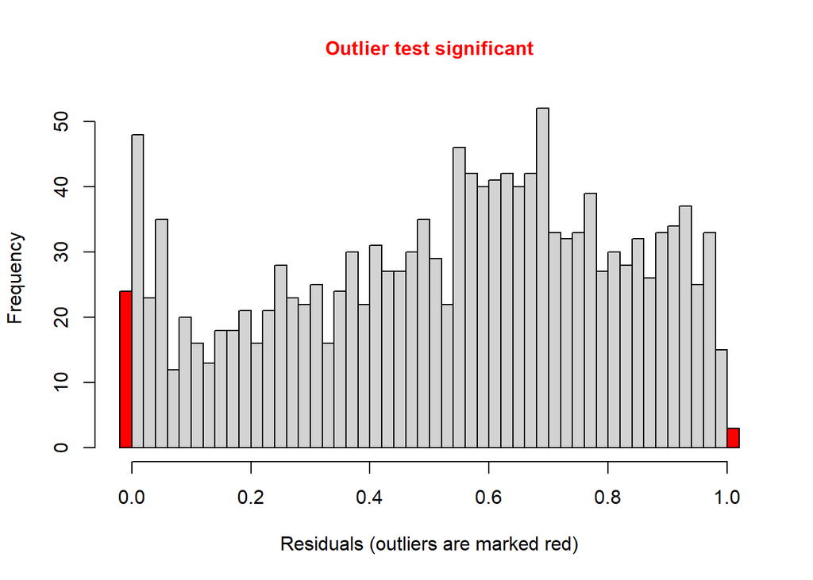

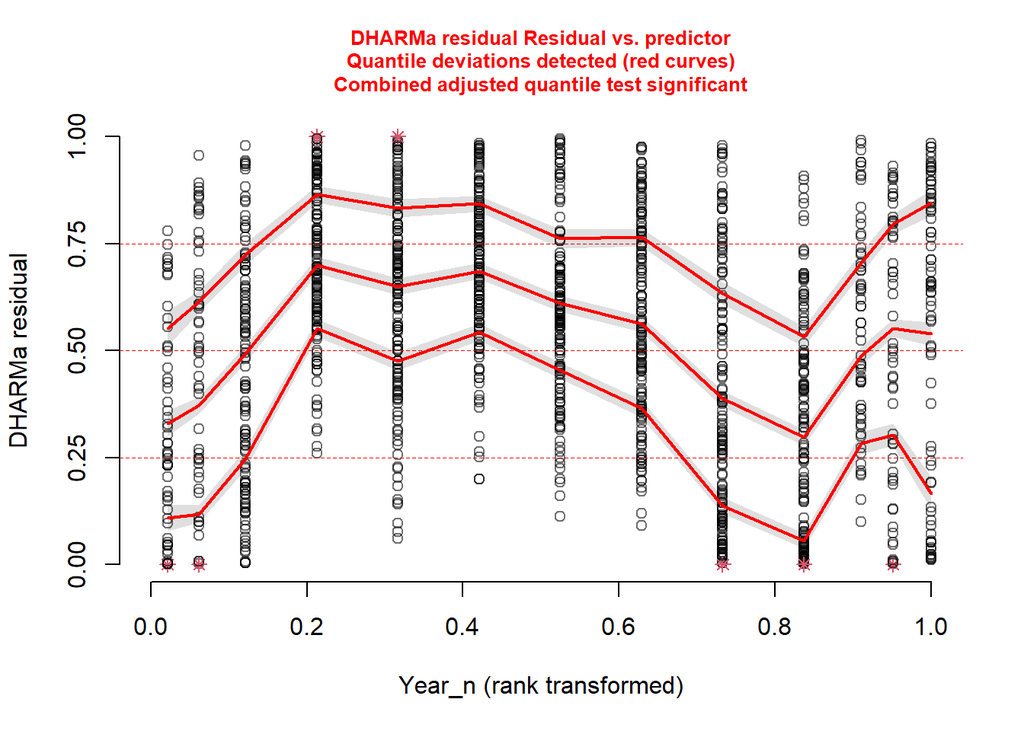

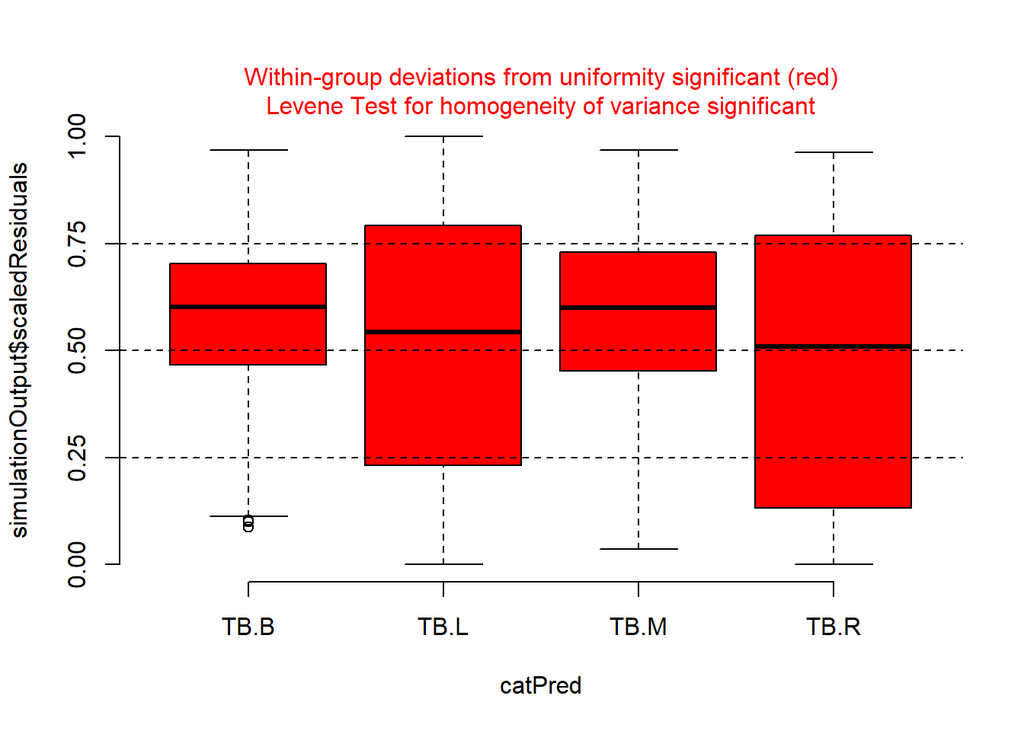

outliers at both margin(s) 37  
Parameter: observations 1481  
p_value: [1] 2.911542e-09  
Conf int: [1] 0.01765003 0.03427272 attr(,“conf.level”) [1] 0.95

Tampa model results

| term | statistic | df | p.value |
| --- | --- | --- | --- |
| SectionID | 10.902 | 3.000 | 0.012 |
| Year_c | 9.992 | 1.000 | 0.002 |
| Quarter | 0.214 | 1.000 | 0.644 |
| SectionID:Year_c | 16.746 | 3.000 | 0.001 |

Emmeans on response scale:

| SectionID | Year_c.trend | SE | df | asymp.LCL | asymp.UCL | annual_pct_change |
| --- | --- | --- | --- | --- | --- | --- |
| TB.B | −0.027 | 0.025 | Inf | −0.076 | 0.021 | −2.688 |
| TB.L | 0.027 | 0.007 | Inf | 0.013 | 0.041 | 2.734 |
| TB.M | 0.013 | 0.023 | Inf | −0.032 | 0.058 | 1.328 |
| TB.R | −0.499 | 0.149 | Inf | −0.791 | −0.206 | −39.269 |

Which sections have different trends?

| contrast | estimate | SE | df | z.ratio | p.value | Significance |
| --- | --- | --- | --- | --- | --- | --- |
| TB.B - TB.L | −0.054 | 0.026 | Inf | −2.097 | 0.154 |  |
| TB.B - TB.M | −0.040 | 0.034 | Inf | −1.198 | 0.628 |  |
| TB.B - TB.R | 0.471 | 0.151 | Inf | 3.114 | 0.010 | ** |
| TB.L - TB.M | 0.014 | 0.024 | Inf | 0.573 | 0.940 |  |
| TB.L - TB.R | 0.526 | 0.149 | Inf | 3.517 | 0.002 | ** |
| TB.M - TB.R | 0.512 | 0.151 | Inf | 3.388 | 0.004 | ** |

Q: Is oyster density increasing or decreasing over time within Sections?:

| SectionID | annual_percent_change | p.value |
| --- | --- | --- |
| TB.B | −2.688 | 0.272 |
| TB.L | 2.734 | 0.000 |
| TB.M | 1.328 | 0.565 |
| TB.R | −39.269 | 0.001 |

Years surveyed per Section

| SectionID | min_year | max_year | n_years |
| --- | --- | --- | --- |
| TB.B | 11.000 | 20.000 | 10.000 |
| TB.L | 1.000 | 20.000 | 13.000 |
| TB.M | 11.000 | 20.000 | 10.000 |
| TB.R | 18.000 | 20.000 | 3.000 |

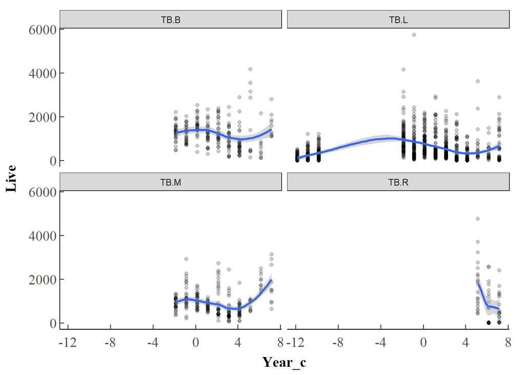

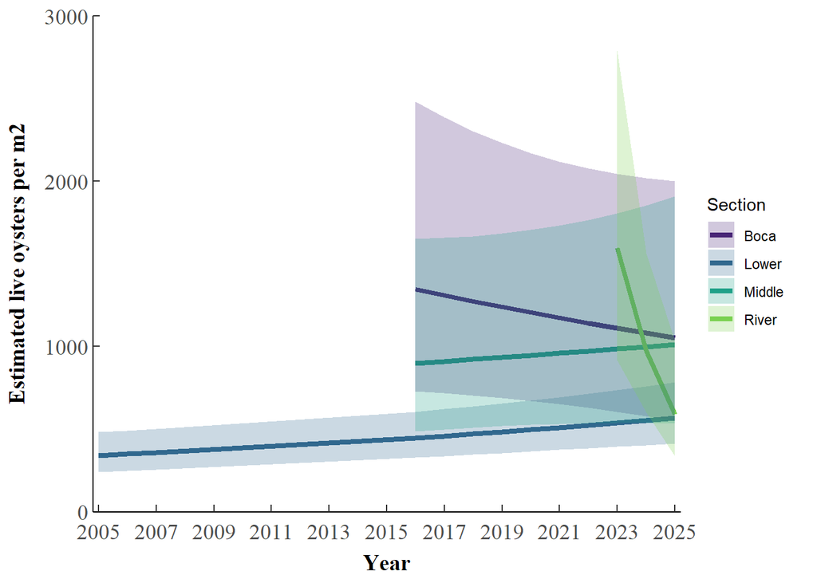

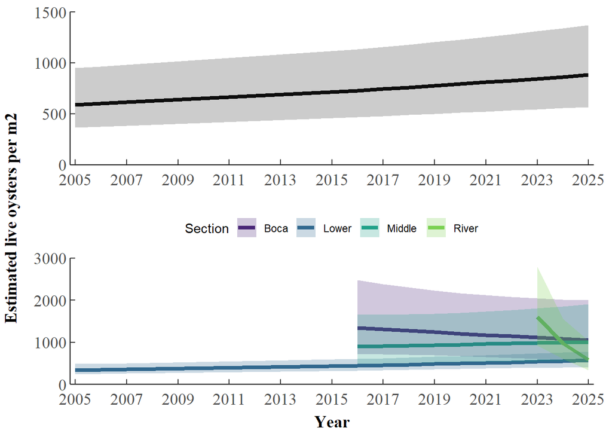

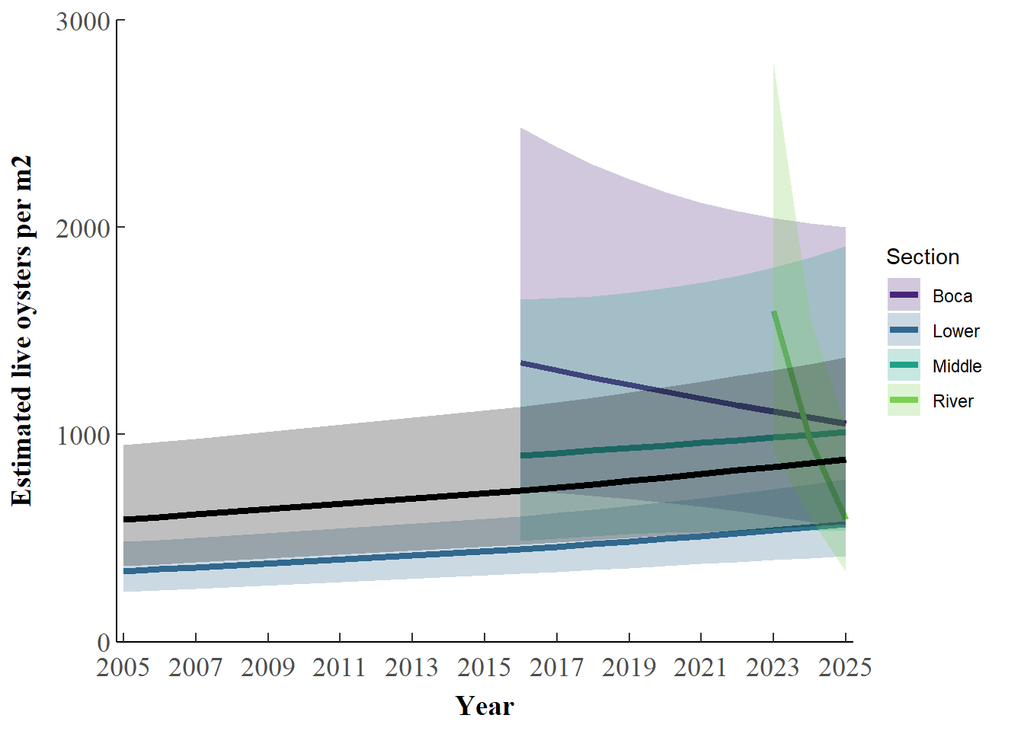

### Sections (spline)

**Spline model assessment:**  
Residuals:

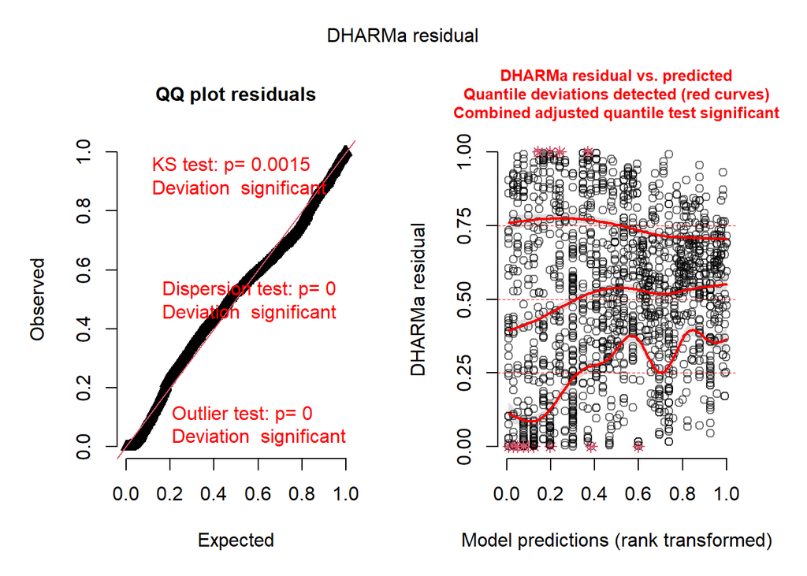

Overdispersion:  
Dispersion ratio > 1 → overdispersion  
Dispersion ratio < 1 → underdispersion

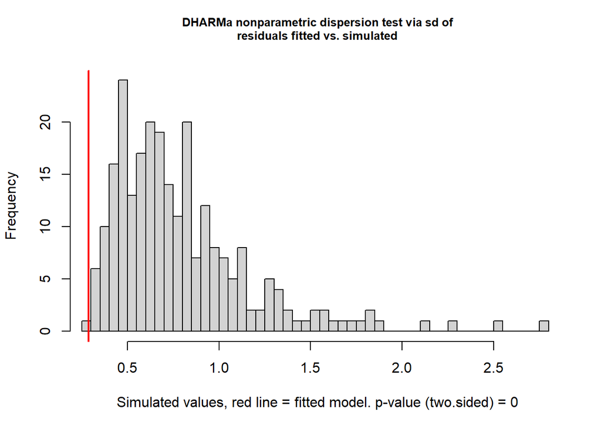

DHARMa nonparametric dispersion test via sd of residuals fitted vs. simulated

data: simulationOutput dispersion = 0.36253, p-value < 2.2e-16 alternative hypothesis: two.sided

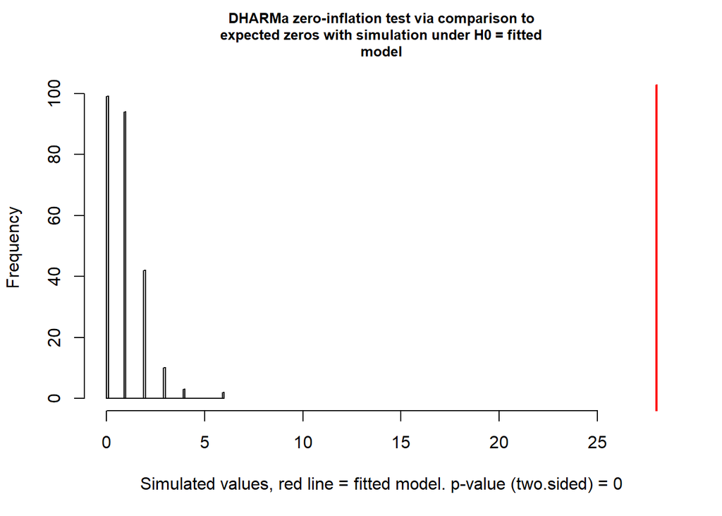

DHARMa zero-inflation test via comparison to expected zeros with simulation under H0 = fitted model

data: simulationOutput ratioObsSim = 30.172, p-value < 2.2e-16 alternative hypothesis: two.sided

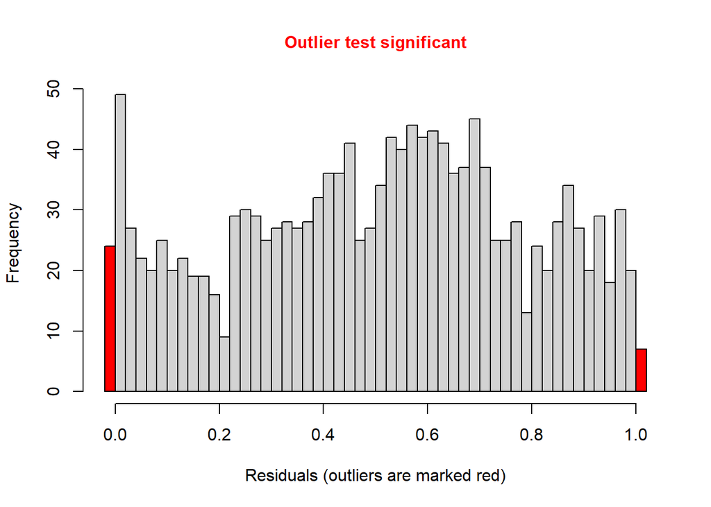

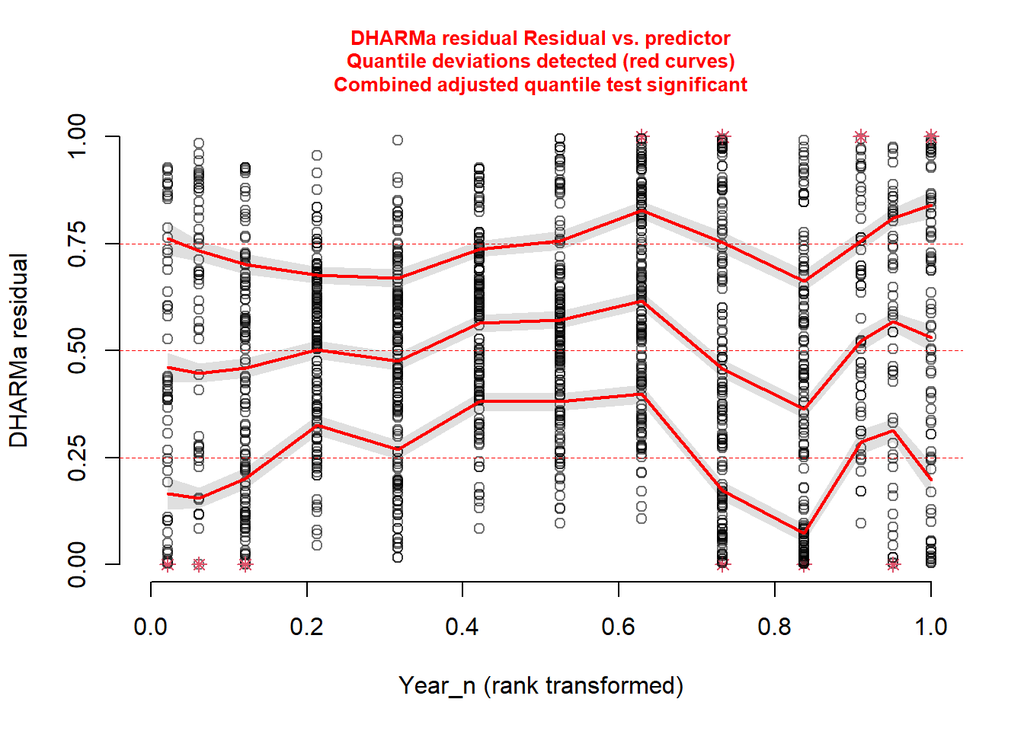

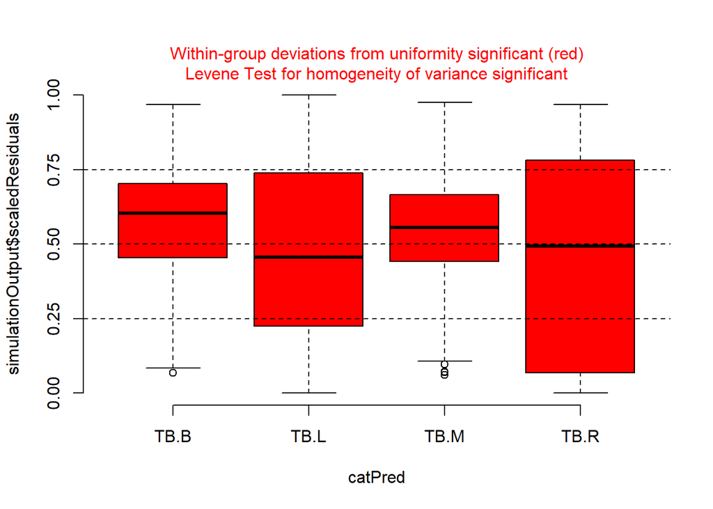

outliers at both margin(s) 43  
Parameter: observations 1481  
p_value: [1] 1.508506e-12  
Conf int: [1] 0.02109033 0.03891147 attr(,“conf.level”) [1] 0.95

Tampa model results

| term | statistic | df | p.value |
| --- | --- | --- | --- |
| SectionID | 8.657 | 3.000 | 0.034 |
| splines::ns(Year_c, df = 3) | 270.943 | 3.000 | 0.000 |
| Quarter | 0.501 | 1.000 | 0.479 |
| SectionID:splines::ns(Year_c, df = 3) | 114.421 | 8.000 | 0.000 |

Emmeans on response scale:

[output not shown]

| contrast | Year_c | ratio | SE | df | null | z.ratio | p.value | Significance |
| --- | --- | --- | --- | --- | --- | --- | --- | --- |
| TB.B / TB.L | -11.8541525995949 | 0.005 | 0.024 | Inf | 1.000 | −1.076 | 0.529 |  |
| TB.B / TB.M | -11.8541525995949 | 767.032 | 5,471.080 | Inf | 1.000 | 0.931 | 0.620 |  |
| TB.B / TB.R | -11.8541525995949 | — | — | — | 1.000 | — | — |  |
| TB.L / TB.M | -11.8541525995949 | 154,552.001 | 798,258.548 | Inf | 1.000 | 2.313 | 0.054 |  |
| TB.L / TB.R | -11.8541525995949 | — | — | — | 1.000 | — | — |  |
| TB.M / TB.R | -11.8541525995949 | — | — | — | 1.000 | — | — |  |
| TB.B / TB.L | 1.14584740040513 | 2.553 | 1.161 | Inf | 1.000 | 2.062 | 0.098 |  |
| TB.B / TB.M | 1.14584740040513 | 1.419 | 0.813 | Inf | 1.000 | 0.611 | 0.814 |  |
| TB.B / TB.R | 1.14584740040513 | — | — | — | 1.000 | — | — |  |
| TB.L / TB.M | 1.14584740040513 | 0.556 | 0.253 | Inf | 1.000 | −1.291 | 0.400 |  |
| TB.L / TB.R | 1.14584740040513 | — | — | — | 1.000 | — | — |  |
| TB.M / TB.R | 1.14584740040513 | — | — | — | 1.000 | — | — |  |
| TB.B / TB.L | 7.14584740040513 | 3.580 | 1.809 | Inf | 1.000 | 2.525 | 0.056 |  |
| TB.B / TB.M | 7.14584740040513 | 0.645 | 0.413 | Inf | 1.000 | −0.685 | 0.903 |  |
| TB.B / TB.R | 7.14584740040513 | 2.030 | 1.153 | Inf | 1.000 | 1.246 | 0.597 |  |
| TB.L / TB.M | 7.14584740040513 | 0.180 | 0.091 | Inf | 1.000 | −3.380 | 0.004 | ** |
| TB.L / TB.R | 7.14584740040513 | 0.567 | 0.234 | Inf | 1.000 | −1.377 | 0.514 |  |
| TB.M / TB.R | 7.14584740040513 | 3.145 | 1.791 | Inf | 1.000 | 2.013 | 0.183 |  |

Start vs End estimated means comps:

| contrast | SectionID | ratio | SE | df | null | z.ratio | p.value | Significance |
| --- | --- | --- | --- | --- | --- | --- | --- | --- |
| (Year_c-11.8541525995949) / Year_c7.14584740040513 | TB.B | 0.001 | 0.003 | Inf | 1.000 | −1.474 | 0.140 |  |
| (Year_c-11.8541525995949) / Year_c7.14584740040513 | TB.L | 0.470 | 0.072 | Inf | 1.000 | −4.919 | 0.000 | *** |
| (Year_c-11.8541525995949) / Year_c7.14584740040513 | TB.M | 0.000 | 0.000 | Inf | 1.000 | −2.763 | 0.006 | ** |
| (Year_c-11.8541525995949) / Year_c7.14584740040513 | TB.R | — | — | — | 1.000 | — | — |  |

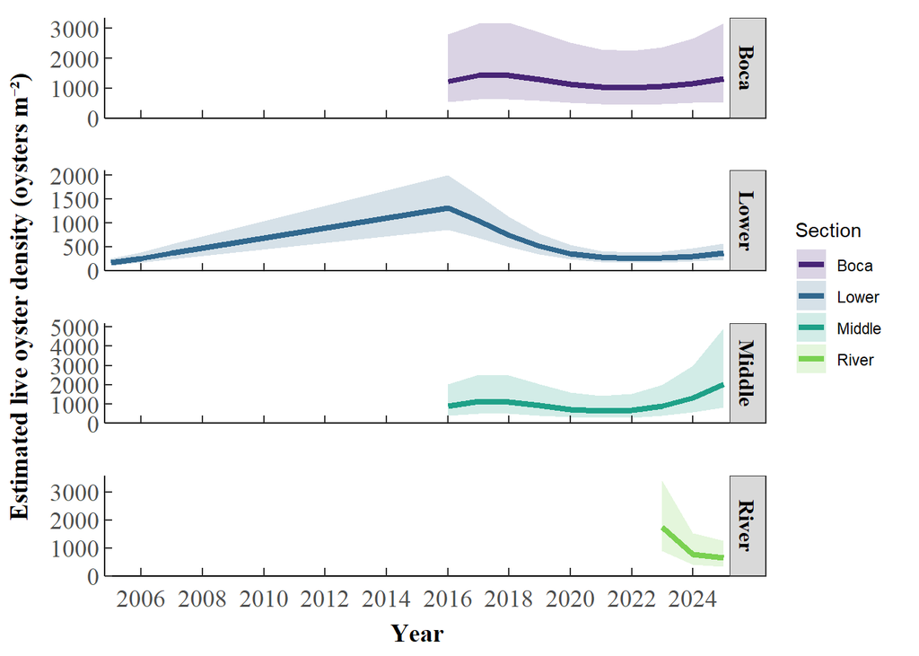